# Senescence Driven Cardiac Fibrosis After Myocardial Infarction, Target Discovery for Anti Fibrotic Gene Therapy

Day 3: Clustering, Ambient RNA Correction, Senescence Scoring, and Annotation

Tehrim Naveed

2026-09-09

```r
library(Seurat)
library(tidyverse)
library(harmony)
library(SingleCellExperiment)
library(zellkonverter)
library(org.Hs.eg.db)
library(msigdbr)
library(AUCell)
library(celda)
library(scDblFinder)
```

# 1. Objective

Clustered and annotated the 46,453 fibroblast nuclei quality controlled in Day 2, corrected for ambient RNA contamination flagged as a known limitation in the original publication, called score for each fibroblast for senescence using two independent methods, identify what each resulting cluster represents using marker genes, and validate my cell population with an independent doublet detection pass.

# 2. Doublet Validation on the Full Dataset

Since doublets are only reliably detectable when more than one cell type is present to simulate against, I ran doublet detection before subsetting to fibroblasts, on the full, all cell type object, using cell_type_original as the clustering variable and donor_id as the sample grouping variable so that detection respects real physical capture boundaries.

```r
sce_full <- readH5AD("data/raw/kuppe_2022_scRNA.h5ad")
counts_full <- assay(sce_full, "X")
meta_full <- as.data.frame(colData(sce_full))
rownames(meta_full) <- colnames(counts_full)
rm(sce_full)
gc()

sce_input_full <- SingleCellExperiment(assays = list(counts = counts_full))

sce_input_full <- scDblFinder(
  sce_input_full,
  clusters = meta_full$cell_type_original,
  samples = meta_full$donor_id
)

meta_full$our_doublet_class <- sce_input_full$scDblFinder.class

table(meta_full$our_doublet_class, meta_full$doublet_score < 0.3)
```

[output not shown]

# 3. Load Fibroblast Data

```r
fibroblasts <- readRDS("data/processed/kuppe_fibroblasts_qc.rds")
dim(fibroblasts)
```

```
## [1] 28380 46453
```

This object already reflects the doublet_score < 0.3 filter applied in Day 2, using the original authors’ own scDblFinder output.

# 4. Normalization, Variable Features, and PCA

```r
fibroblasts <- NormalizeData(fibroblasts)
fibroblasts <- FindVariableFeatures(fibroblasts, selection.method = "vst", nfeatures = 2000)
```

I used the vst method since it selects genes based on variance relative to expression level, preventing highly expressed genes from dominating selection purely due to scale. Among the top variable genes were SERPINE1, POSTN, and FN1, established markers of myofibroblast activity and the senescence associated secretory phenotype, an early signal that this fibroblast population carries the biology this project is built around.

Two of the top ten variable genes, ENSG00000285861 and ENSG00000286922, mapped to long non coding RNAs currently annotated only as “novel transcript” with no established function, confirmed directly against the Ensembl REST API. I retained these in the analysis rather than excluding them, since their role is currently unknown rather than ruled out, and did not filter non coding genes from the variable feature set at any point.

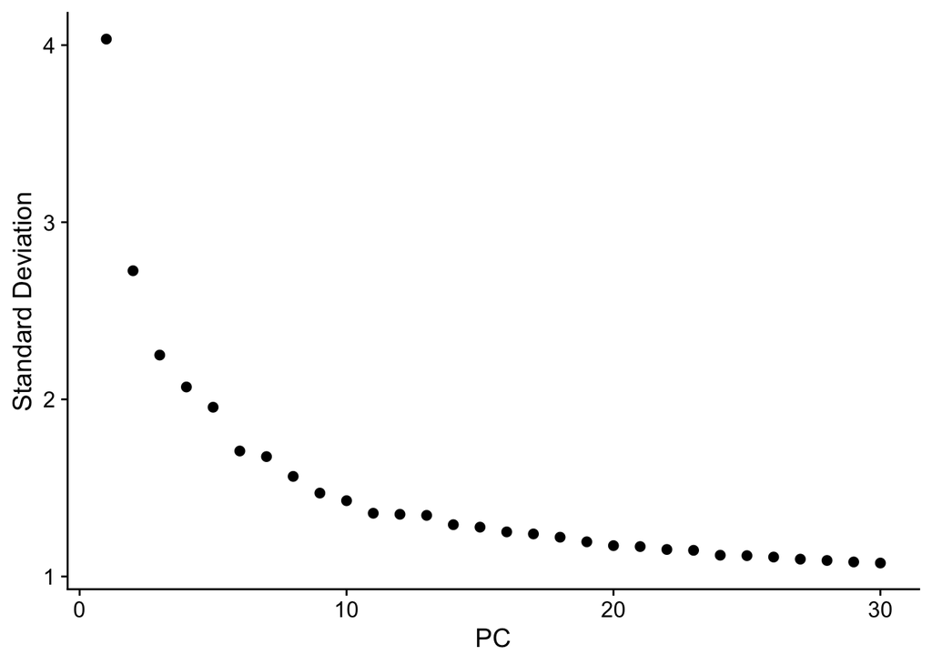

```r
fibroblasts <- ScaleData(fibroblasts, features = VariableFeatures(fibroblasts))
fibroblasts <- RunPCA(fibroblasts, features = VariableFeatures(fibroblasts))

ElbowPlot(fibroblasts, ndims = 30)
```

I selected fifteen principal components for downstream steps, based on the elbow plot flattening substantially by around PC10 to PC12.

# 5. Ambient RNA Correction

Kuppe et al. 2022 report that necrotic tissue in the ischemic zone releases ambient RNA that can contaminate neighboring nuclei during capture, and flag this as a limitation in their own analysis that was not computationally corrected. Given this, I applied DecontX, which estimates and removes ambient contamination directly from the filtered count matrix, appropriate here since the raw, unfiltered droplet matrix needed for tools like SoupX or CellBender is not available through this dataset’s public distribution.

```r
fibroblasts <- RunHarmony(
  fibroblasts,
  group.by.vars = "donor_id",
  reduction.use = "pca",
  dims.use = 1:15
)
```

```
## Initializing centroids
```

```r
fibroblasts <- FindNeighbors(fibroblasts, reduction = "harmony", dims = 1:15)
fibroblasts <- FindClusters(fibroblasts, resolution = 0.5)
```

```
## Modularity Optimizer version 1.3.0 by Ludo Waltman and Nees Jan van Eck
##
## Number of nodes: 46453
## Number of edges: 975367
##
## Running Louvain algorithm...
## Maximum modularity in 10 random starts: 0.7995
## Number of communities: 7
## Elapsed time: 7 seconds
```

I used this initial clustering to inform DecontX’s contamination model, which estimates each cell’s deviation from its assigned cluster’s expected expression profile.

```r
counts_matrix <- GetAssayData(fibroblasts, layer = "counts")

decontx_results <- decontX(counts_matrix, z = fibroblasts@meta.data$seurat_clusters)

fibroblasts@meta.data$contamination <- decontx_results$contamination

decontx_counts <- decontx_results$decontXcounts

fibroblasts[["decontX"]] <- CreateAssay5Object(counts = decontx_counts)
DefaultAssay(fibroblasts) <- "decontX"
```

I added the decontaminated counts as a separate assay rather than overwriting the original counts, keeping both available for comparison. By running DecontX before finalizing clusters, I address ambient contamination directly at the source, going a step further than the original publication, which flagged the issue but did not apply a computational correction.

# 6. Final Clustering

```r
fibroblasts <- NormalizeData(fibroblasts)
fibroblasts <- FindVariableFeatures(fibroblasts, selection.method = "vst", nfeatures = 2000)
fibroblasts <- ScaleData(fibroblasts, features = VariableFeatures(fibroblasts))
fibroblasts <- RunPCA(fibroblasts, features = VariableFeatures(fibroblasts))

fibroblasts <- RunHarmony(
  fibroblasts,
  group.by.vars = "donor_id",
  reduction.use = "pca",
  dims.use = 1:15,
  reduction.save = "harmony_decontx"
)
```

```
## Initializing centroids
```

```r
fibroblasts <- RunUMAP(fibroblasts, reduction = "harmony_decontx", dims = 1:15, reduction.name = "umap_decontx")
fibroblasts <- FindNeighbors(fibroblasts, reduction = "harmony_decontx", dims = 1:15)
fibroblasts <- FindClusters(fibroblasts, resolution = 0.5)
```

```
## Modularity Optimizer version 1.3.0 by Ludo Waltman and Nees Jan van Eck
##
## Number of nodes: 46453
## Number of edges: 1302080
##
## Running Louvain algorithm...
## Maximum modularity in 10 random starts: 0.9015
## Number of communities: 9
## Elapsed time: 10 seconds
```

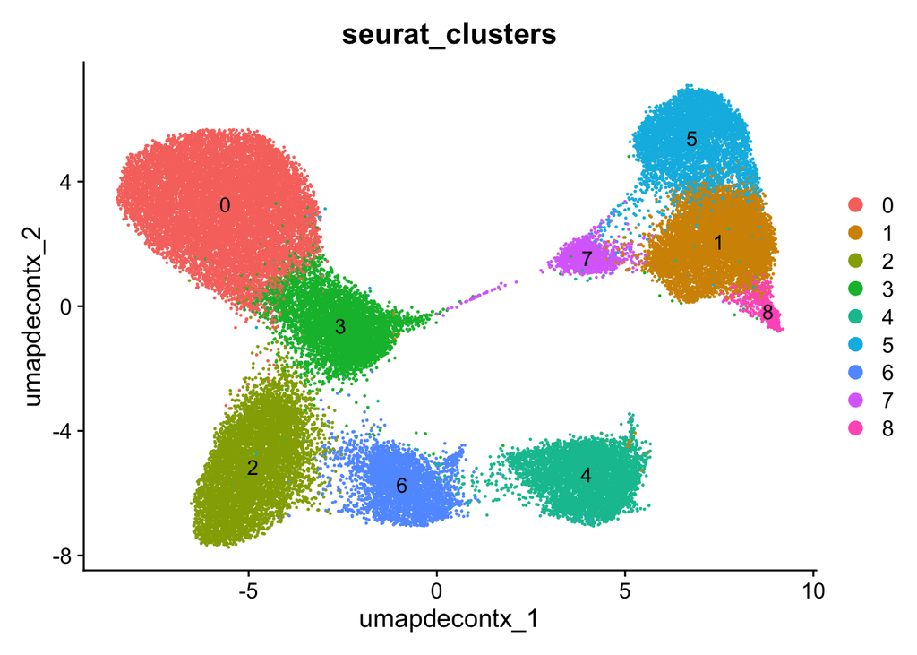

```r
DimPlot(fibroblasts, reduction = "umap_decontx", group.by = "seurat_clusters", label = TRUE)
```

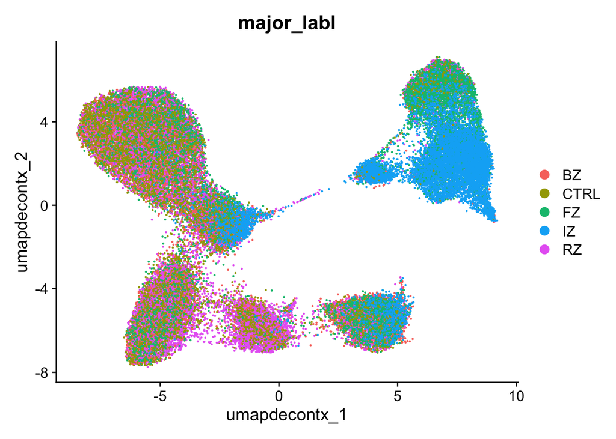

```r
DimPlot(fibroblasts, reduction = "umap_decontx", group.by = "major_labl")
```

This produced nine clusters on the ambient RNA corrected data. The ischemic zone remained clearly separated from the other four zones even after this correction, indicating a genuine transcriptional difference in IZ fibroblasts, consistent with the necrosis associated stress response described in the original publication, rather than a technical artifact.

# 7. Senescence Scoring

I scored senescence using the SenMayo gene set (Saul et al. 2022), pulled directly from MSigDB for reproducibility.

```r
senmayo <- msigdbr(species = "Homo sapiens", collection = "C2", subcollection = "CGP") %>%
  filter(gs_name == "SAUL_SEN_MAYO")

senmayo_ids <- unique(na.omit(senmayo$ensembl_gene))
senmayo_in_data <- senmayo_ids[senmayo_ids %in% rownames(fibroblasts)]

length(senmayo_ids)
```

```
## [1] 124
```

```r
length(senmayo_in_data)
```

```
## [1] 116
```

124 of the 125 published SenMayo genes were available in MSigDB’s current build, and 116 of those were present as measured features in this dataset.

```r
fibroblasts <- AddModuleScore(
  fibroblasts,
  features = list(senmayo_in_data),
  name = "SenMayo"
)
```

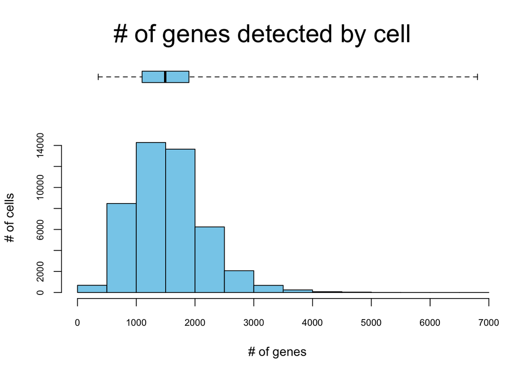

```
##  min   1%   5%  10%  50% 100%
##  353  483  625  781 1493 6807
```

```r
expr_matrix <- GetAssayData(fibroblasts, layer = "counts")
gene_sets <- list(SenMayo = senmayo_in_data)

cell_rankings <- AUCell_buildRankings(expr_matrix, plotStats = TRUE)
```

```r
cell_auc <- AUCell_calcAUC(gene_sets, cell_rankings)

fibroblasts@meta.data$SenMayo_AUCell <- as.numeric(getAUC(cell_auc)["SenMayo", ])
```

I scored senescence with two independent methods. AddModuleScore compares average expression against a matched control gene set, while AUCell ranks genes within each cell rather than comparing expression magnitude directly, making it less sensitive to depth differences between cells.

```r
cor(fibroblasts@meta.data$SenMayo1, fibroblasts@meta.data$SenMayo_AUCell, method = "spearman")
```

```
## [1] 0.8656447
```

I used Spearman correlation because the two scores sit on fundamentally different scales, AddModuleScore is zero centered and can be negative, AUCell is bounded between 0 and 1, so comparing relative ordering rather than raw magnitude is the appropriate test. The two methods showed a Spearman correlation of 0.87, strong agreement despite being built on independent statistical logic, which gives me confidence this senescence signal reflects real biology rather than an artifact of either method’s assumptions.

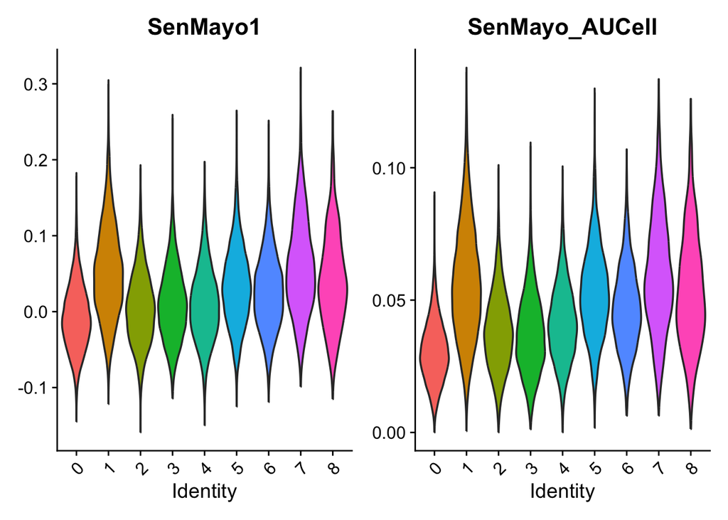

```r
VlnPlot(fibroblasts, features = c("SenMayo1", "SenMayo_AUCell"), group.by = "seurat_clusters", pt.size = 0)
```

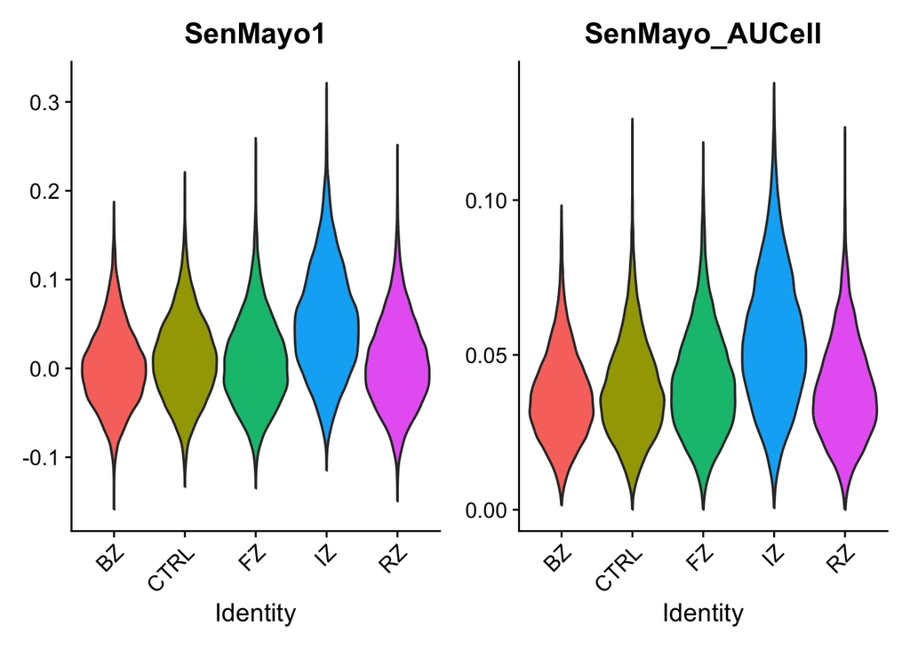

```r
VlnPlot(fibroblasts, features = c("SenMayo1", "SenMayo_AUCell"), group.by = "major_labl", pt.size = 0)
```

Both scores were highest in clusters 1, 7, and 8, and highest overall in the IZ zone. I annotated each cluster by marker genes next, to establish which of these are genuine fibroblast populations before drawing conclusions from the scores.

# 8. Cluster Annotation

```r
markers <- FindAllMarkers(fibroblasts, only.pos = TRUE, min.pct = 0.25, logfc.threshold = 0.25)

top_markers <- markers %>%
  group_by(cluster) %>%
  slice_max(order_by = avg_log2FC, n = 10)

top_markers$gene_symbol <- mapIds(
  org.Hs.eg.db,
  keys = top_markers$gene,
  keytype = "ENSEMBL",
  column = "SYMBOL"
)
```

Based on top marker genes, I identified the following cluster identities:

Cluster 0, quiescent fibroblasts: ACSM1, ACSM3, ADH1B, FMO2, metabolic and detoxification genes consistent with homeostatic, baseline fibroblasts.

Cluster 2, quiescent fibroblasts: SCARA5, PCOLCE2, established markers of resident cardiac fibroblasts.

Cluster 4, activated myofibroblasts: MEOX1, THBS4, FAP, POSTN, TNC, LOXL1, the matrix producing, disease relevant fibroblast state central to this project.

Cluster 5, acutely stressed fibroblasts: FOSB, NR4A1, PER2, immediate early genes, enriched in the fibrotic zone.

Cluster 1, ischemic zone associated fibroblasts, elevated senescence score: this cluster carries a metabolic and stress associated marker profile consistent with fibroblast identity, and is the clearest senescence signal in a genuine fibroblast population in this dataset.

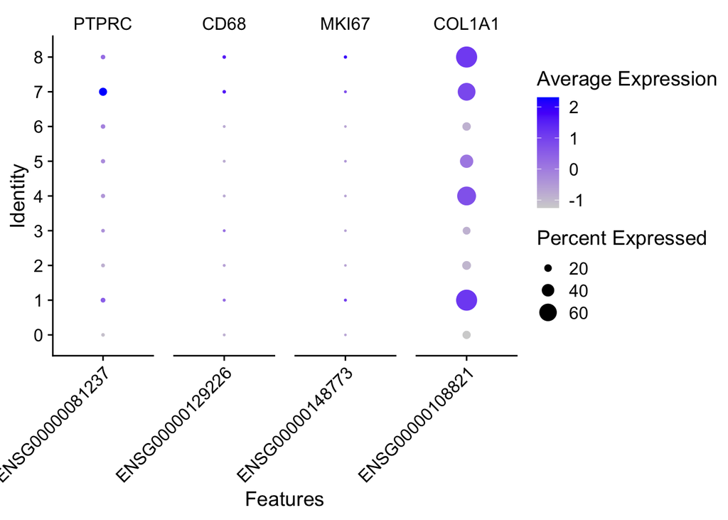

```r
canonical_ids <- mapIds(
  org.Hs.eg.db,
  keys = c("PTPRC", "CD68", "MKI67", "COL1A1"),
  keytype = "SYMBOL",
  column = "ENSEMBL"
)

DotPlot(fibroblasts, features = canonical_ids, group.by = "seurat_clusters") + RotatedAxis()
```

Clusters 7 and 8, by contrast, expressed canonical macrophage markers (CD163, MSR1, STAB1, MERTK, PTPRC, CD68) and cell cycle genes (MKI67, FANCA, BRIP1, MELK, UHRF1) respectively, alongside detectable COL1A1, consistent with fibroblast-immune and fibroblast-proliferating cell doublets rather than pure fibroblast populations. I excluded both from downstream fibroblast specific analysis on this basis, standard practice when marker evidence contradicts an original cell type label.

Cluster 3 shows some cardiomyocyte marker expression (TNNI3, MYL2, MYH7) alongside fibroblast genes, which I am carrying forward as a specific point to investigate further in Day 4, rather than excluding outright given the less clear cut evidence compared to clusters 7 and 8.

```r
fibroblasts_clean <- subset(
  fibroblasts,
  subset = seurat_clusters %in% c("7", "8"),
  invert = TRUE
)

dim(fibroblasts_clean)
```

```
## [1] 28380 44513
```

```r
table(fibroblasts_clean@meta.data$seurat_clusters, fibroblasts_clean@meta.data$major_labl)
```

```
##
##       BZ CTRL   FZ   IZ   RZ
##   0 1919 4231 2454   77 3564
##   1  163   31 1297 5834   66
##   2  915 1998  959   32 2611
##   3  884 1214 1023  880 1256
##   4 1835  478 1363  624  658
##   5  177  616 2283 1025  791
##   6  297  704  140   25 2089
##   7    0    0    0    0    0
##   8    0    0    0    0    0
```

I also checked this cleaned population against the full dataset doublet detection results from Section 2. 533 fibroblasts (1.2 percent) were flagged by my independent run but not the original filter, mildly enriched in cluster 1 (2.6 percent versus 0.6 to 1.5 percent in other clusters). Given the known variability in individual doublet calls between independent runs described earlier, I did not remove these cells, and instead note this as context for interpreting cluster 1 specifically, alongside its comparatively lower sequencing depth.

```r
additional_doublets <- rownames(meta_full)[
  meta_full$our_doublet_class == "doublet" & meta_full$doublet_score < 0.3
]

fibroblasts_clean@meta.data$additional_flag <- colnames(fibroblasts_clean) %in% additional_doublets

table(fibroblasts_clean@meta.data$additional_flag, fibroblasts_clean@meta.data$seurat_clusters)
```

[output not shown]

# 9. Save Output

```r
saveRDS(fibroblasts_clean, "data/processed/kuppe_fibroblasts_final.rds")
```

# 10. Summary

I corrected for ambient RNA contamination flagged in the original publication using DecontX, applied before finalizing clusters, which confirmed the ischemic zone’s transcriptional distinctness reflects real biology rather than a technical artifact. I scored senescence using two independent methods with strong agreement (Spearman rho = 0.87), then used marker gene analysis to confirm cluster identities, which allowed me to exclude two clusters that were immune and proliferating cell populations rather than fibroblasts. The resulting population, cluster 1 specifically, represents a fibroblast population with a genuine, corroborated senescence signal, interpreted alongside its comparatively lower sequencing depth and a modest doublet enrichment flagged by independent validation. Cluster 3’s partial cardiomyocyte marker expression is carried forward as a specific point for further investigation in Day 4.